# The 2018 TRHL auction

The 2018 TRHL auction began February 6, 2019 and ended on March 18. This document offers some graphical views of the auction.

#### Bidding patterns

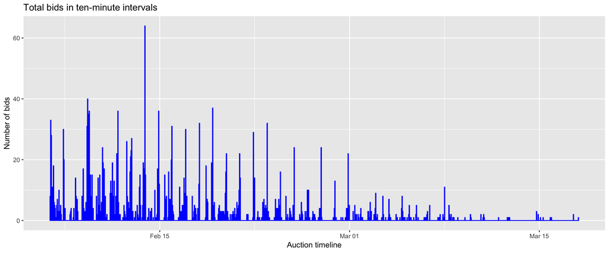

The following graph shows the total number of bids that occurred between deadlines during the auction, divided into one-minute intervals.

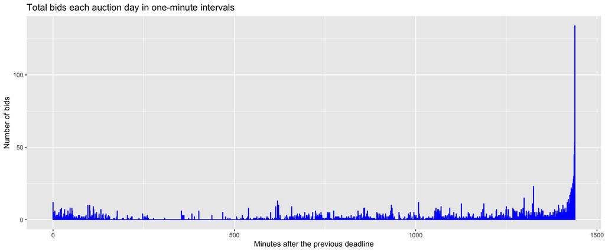

#### Bidding on individual players

The lines show the bidding history for all players in the TRHL auction, with the winning bid indicated in green. The point at which the player sold is shown by “$”, with the size of the symbol proportional to the player’s 2018 fWAR.

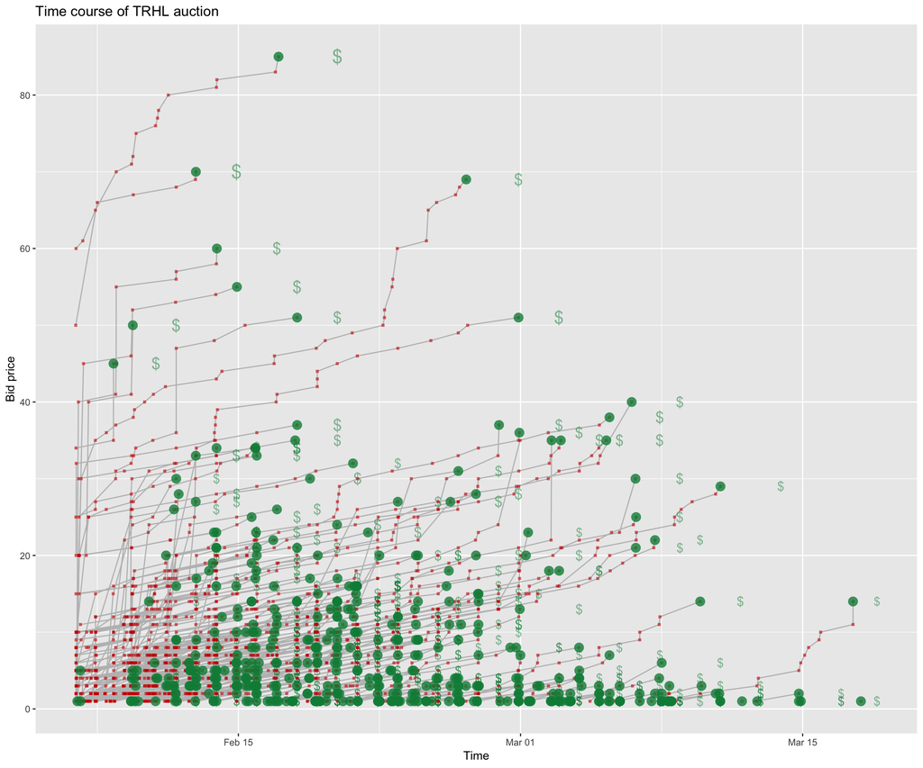

#### Bidding by team

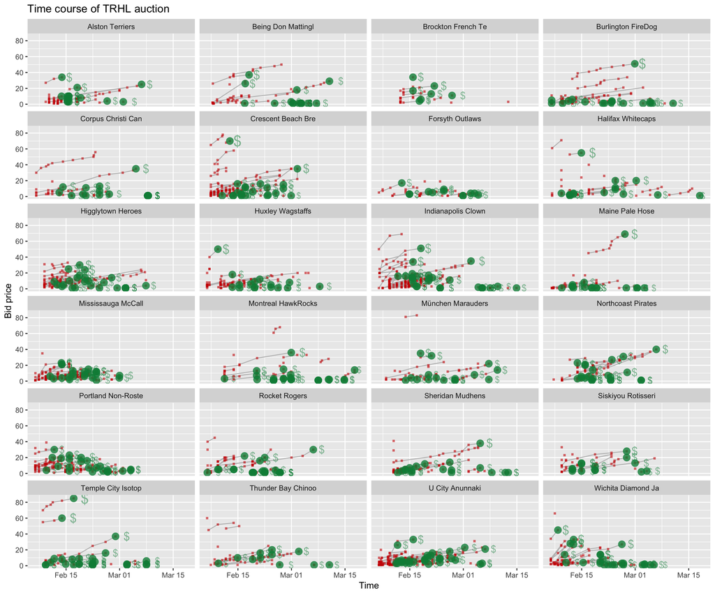

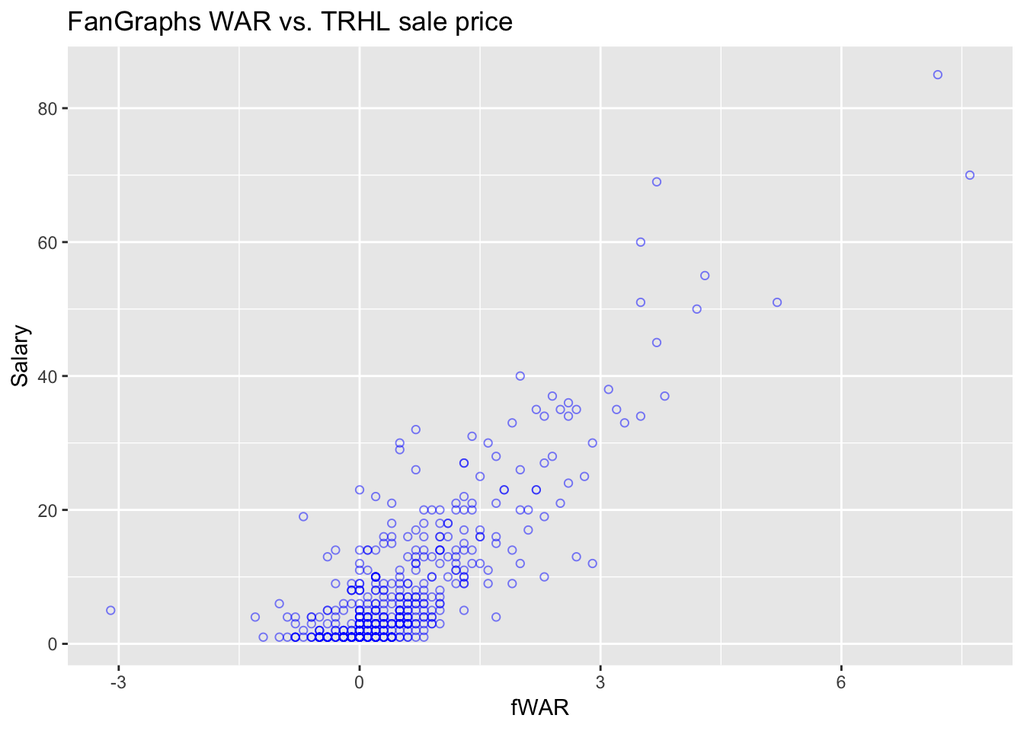

The player on the far left is Chris Davis, and the two on the far right are Max Scherzer and Francisco Lindor.

#### Auction inflation

This graph shows the cumulative amount spent on sold players for each day of the auction in green, with an overlay in blue showing cumulative fWAR bought. The fWAR total is multiplied by 12 for visualization purposes. The red line shows the amount of available money at the beginning of the auction.

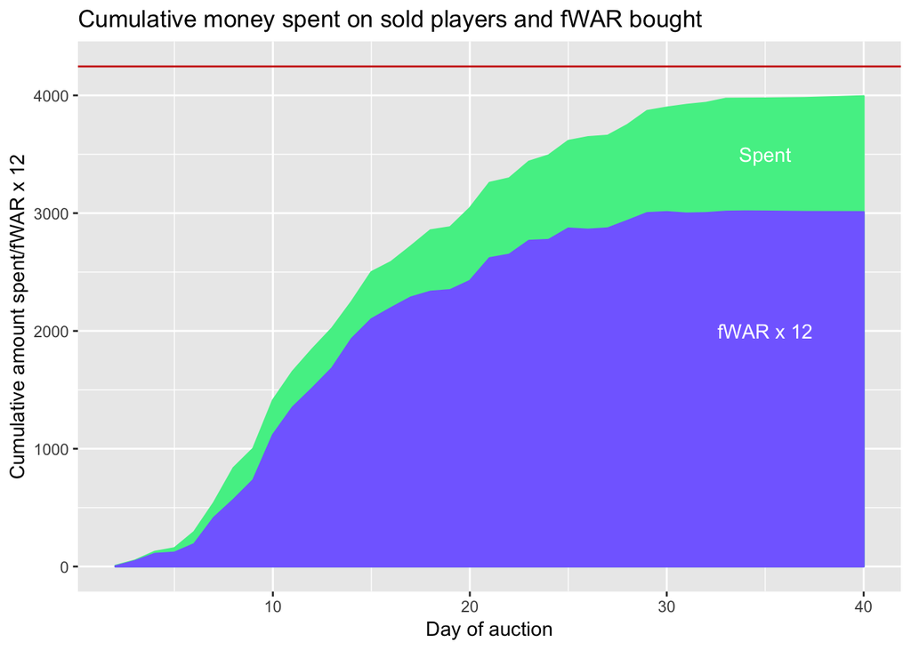

#### Players who took the longest to sell after the opening bid

| UID | Player | Team | sale_dur | Salary | fWAR |
| --- | --- | --- | --- | --- | --- |
| 31232 | Hirano,Yoshihisa | Being Don Mattingl | 765.5275 hours | 29 | 0.5 |
| 29085 | Myers,Wil | Rocket Rogers | 717.7875 hours | 30 | 1.6 |
| 31424 | Toussaint,Touki | U City Anunnaki | 707.0989 hours | 21 | 0.4 |
| 28166 | Robertson,David | Alston Terriers | 704.3522 hours | 25 | 1.5 |
| 27185 | Hamels,Cole | Northcoast Pirates | 700.8581 hours | 40 | 2.0 |
| 29386 | Pederson,Joc | Corpus Christi Can | 690.0947 hours | 35 | 2.7 |
| 27768 | Upton,Justin | Sheridan Mudhens | 677.3503 hours | 38 | 3.1 |
| 28792 | Darvish,Yu | München Marauders | 669.3914 hours | 22 | 0.2 |
| 29832 | McCullers,Lance | Indianapolis Clown | 635.0989 hours | 35 | 2.5 |
| 30013 | Schwarber,Kyle | Crescent Beach Bre | 622.3150 hours | 35 | 3.2 |

#### Players receiving the most bids

| Player | bids |
| --- | --- |
| Acuna,Ronald | 31 |
| McCullers,Lance | 28 |
| Hirano,Yoshihisa | 26 |
| Muncy,Max | 25 |
| Hamels,Cole | 24 |
| McCutchen,Andrew | 22 |
| Robertson,David | 22 |
| Darvish,Yu | 20 |
| Myers,Wil | 20 |
| Pederson,Joc | 20 |

#### Teams making the most bids

| Team | bids |
| --- | --- |
| Indianapolis Clown | 206 |
| U City Anunnaki | 202 |
| Crescent Beach Bre | 165 |
| Mississauga McCall | 158 |
| Portland Non-Roste | 151 |
| Higglytown Heroes | 138 |
| Wichita Diamond Ja | 125 |
| Burlington FireDog | 110 |
| Huxley Wagstaffs | 102 |
| Rocket Rogers | 102 |